# SPATA2_V4_test_targets_Optimised_subscript

## Setup + Loading Required Libraries:

Ensure Seurat V = 5.0.3 & SPATA2 V = 2.0.4

## Outputs That will be generated:

2 total pval-miRNA Heatmap outputs (1 count matricx and 2 types of clustering):

- kmeans cluster df with log1p normalised corrected count matrix
- bayes_space cluster df with log1p normalised corrected count matrix

```r
# Use this code to load up the dataset which has
# already been clustered and denoised or comment out

main_spata2_obj_hi_res <- readRDS("~/MSc_Dissertation_Analysis_Folder_Legion/SPATA/SPATA2_Master_Analysis_Folder/RDS_Files_V3_Script/GSE188888_Heart_V3/GSM5691527_Sample_C7d_V3_denoised.rds")

sample_name_here <- getSampleName(main_spata2_obj_hi_res)
print(sample_name_here)
```

```
## [1] "GSM5691527_Sample_C7d_V3"
```

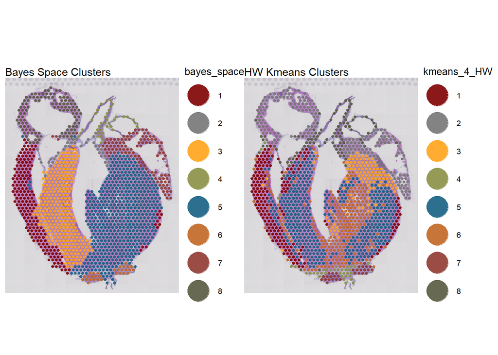

```r
# Create the first plot
plot1 <- plotSurface(
  object = main_spata2_obj_hi_res,
  color_by = "bayes_space",
  pt_size = 2.3,
  pt_clrp = "uc"
) +
labs(subtitle = "Bayes Space Clusters") +
theme(
  legend.text = element_text(size = 8),  # Adjust legend text size
  legend.title = element_text(size = 10) # Adjust legend title size
)

# Create the second plot
plot2 <- plotSurface(
  object = main_spata2_obj_hi_res,
  color_by = "kmeans_4_HW",
  pt_clrp = "uc",
  pt_size = 2.3
) +
labs(subtitle = "HW Kmeans Clusters") +
theme(
  legend.text = element_text(size = 8),  # Adjust legend text size
  legend.title = element_text(size = 10) # Adjust legend title size
)


# Combine the plots side by side
combined_plot <- plot1 | plot2

# Display the combined plot
print(combined_plot)
```

## If marker genes are known, Make plots

## Start of the script to generate heatmaps

Begin by storing the input file paths as objects in R. This makes file handling much easier and efficient. Note how the variable names are short yet informative. Then read these files into objects and check the dimensions of the objects to ensure there is no loss of data. The last line of code in this chunk checks if the cluster table has been made correctly by checking if all the barcodes from the expression table are present in the cluster table using all(). Outputs TRUE if it is correct.

When added to the main script, the file reading part will be skipped and the expression matrix and the cluster df can be easily created or obtained using get..() from SPATA2.

```r
# 2 objects to be created
# exp matrix
# df with barcodes and cluster numbers

getSampleName(main_spata2_obj_hi_res)
```

```
## [1] "GSM5691527_Sample_C7d_V3"
```

```r
# get count matrix and convert them to dataframes
exp_matrix_scaled <- getCountMatrix(main_spata2_obj_hi_res)
exp_matrix_scaled <- as.data.frame(exp_matrix_scaled)

#log1p normalise
exp_matrix_scaled <- log1p(exp_matrix_scaled)

# Get the feature df
feature_df_full <- getFeatureDf(main_spata2_obj_hi_res)

# retain only all columns except barcodes and cluster numbers for kmeans/bayesspace
final_feature_df_kmeans <- feature_df_full %>%
  dplyr::select(barcodes, kmeans_4_HW)

# Set the barcodes as row names directly
# kmeans
final_feature_df_kmeans <- final_feature_df_kmeans %>%
  column_to_rownames(var = "barcodes")

# Bayes_space
final_feature_df_bayesspace <- feature_df_full %>%
  dplyr::select(barcodes, bayes_space)

final_feature_df_bayesspace <- final_feature_df_bayesspace %>%
  column_to_rownames(var = "barcodes")

# Need to read in targets file from targetscan
# Change the file path as needed
targetsFile_Mouse <- "~/MSc_Dissertation_Analysis_Folder_Legion/SPATA/SPATA2_Master_Analysis_Folder/Targetscan_Data/MMS_Predicted_Targets_Context_Scores.default_predictions.txt"


# Set the final target file to use in this execution
targetsFile <- targetsFile_Mouse
```

## SPATA2 Object derived objects used downstream instead of reading files

Change the cluster table for each iteration.

```r
# Read the files into object
expTabScaled <- exp_matrix_scaled

cluTab_kmeans <- final_feature_df_kmeans
cluTab_bayesspaces <- final_feature_df_bayesspace

# Setting this as the whole code uses expTab
# This iteration: kmeans & scaled
expTab <- expTabScaled
cluTab <- cluTab_kmeans
tarTab <- read.table(targetsFile, sep = "\t", header = TRUE, check.names = FALSE)

# check the files to see if it has been read in correctly
# Check data
dim(expTab)
```

```
## [1] 13681  1374
```

```r
dim(cluTab)
```

```
## [1] 1374    1
```

```r
dim(tarTab)
```

```
## [1] 1516846      12
```

```r
expTab[1:5, 1:5]
```

|  | AAACCGGGTAGGTACC-1 | AAACCGTTCGTCCAGG-1 | AAACGAGACGGTTGAT-1 | AAACTGCTGGCTCCAA-1 | AAAGGCTCTCGCGCCG-1 |
| --- | --- | --- | --- | --- | --- |
| Sox17 | 0.6931472 | 0.0000000 | 0.0000000 | 0.000000 | 0.000000 |
| Mrpl15 | 0.0000000 | 0.6931472 | 1.0986123 | 1.098612 | 1.386294 |
| Lypla1 | 1.0986123 | 0.6931472 | 0.0000000 | 1.098612 | 0.000000 |
| Tcea1 | 0.0000000 | 0.6931472 | 0.0000000 | 0.000000 | 0.000000 |
| Atp6v1h | 0.0000000 | 0.6931472 | 0.6931472 | 1.098612 | 0.000000 |

```r
head(cluTab)
```

|  | kmeans_4_HW |
| --- | --- |
| AAACCGGGTAGGTACC-1 | 1 |
| AAACCGTTCGTCCAGG-1 | 1 |
| AAACGAGACGGTTGAT-1 | 6 |
| AAACTGCTGGCTCCAA-1 | 6 |
| AAAGGCTCTCGCGCCG-1 | 6 |
| AAAGGGCAGCTTGAAT-1 | 1 |

```r
head(tarTab)
```

|  | Gene ID | Gene Symbol | Transcript ID | Gene Tax ID | miRNA | Site Type | UTR_start | UTR end | context++ score | context++ score percentile | weighted context++ score | weighted context++ score percentile |
| --- | --- | --- | --- | --- | --- | --- | --- | --- | --- | --- | --- | --- |
| 1 | ENSMUSG00000021252.6 | 0610007P14Rik | ENSMUST00000021676.6 | 9544 | mml-miR-7 | 2 | 31 | 37 | -0.298 | 95 | -0.298 | 97 |
| 2 | ENSMUSG00000021252.6 | 0610007P14Rik | ENSMUST00000021676.6 | 9544 | mml-miR-493-5p | 3 | 182 | 189 | -0.501 | 99 | -0.501 | 99 |
| 3 | ENSMUSG00000021252.6 | 0610007P14Rik | ENSMUST00000021676.6 | 9544 | mml-miR-330-5p | 2 | 404 | 410 | -0.197 | 89 | -0.197 | 93 |
| 4 | ENSMUSG00000021252.6 | 0610007P14Rik | ENSMUST00000021676.6 | 9544 | mml-miR-129-2-3p | 2 | 422 | 428 | -0.274 | 94 | -0.273 | 96 |
| 5 | ENSMUSG00000021252.6 | 0610007P14Rik | ENSMUST00000021676.6 | 9544 | mml-miR-129-1-3p | 2 | 422 | 428 | -0.274 | 94 | -0.273 | 96 |
| 6 | ENSMUSG00000021252.6 | 0610007P14Rik | ENSMUST00000021676.6 | 9544 | mml-miR-16-5p | 2 | 466 | 472 | -0.105 | 70 | 0.000 | 0 |

```r
# All barcodes from expression table should be in the cluster table
# This should output TRUE if it is so
all(colnames(expTab) %in% rownames(cluTab))
```

```
## [1] TRUE
```

## Defining miRNAs & topN

Here, the miRNAs to be parsed for in the Targetscan file are defined. Also, how many of the top ‘n’ targets should be used for each cluster is also set here which can be changed as desired depending on how many targets are present in the dataset from the list of top targets obtained from the targetscan file.

More microRNAs should not be added as this will increase the problem of multiple testing and let-7a is the negative control here.

```r
# which miRNAs are we going to test?
# This doesn't need to be changed
mirs <- c("mmu-miR-124-3p.1", "mmu-miR-9-5p", "mmu-miR-122-5p", "mmu-miR-1a-3p", "mmu-miR-133a-3p.1",
          "mmu-let-7a-5p")

# How many top targets for each miRNA?
# This can be changed as needed
topN <- 100
```

## Number of barcodes in each cluster

Here we will use the table() to build frequency tables to see how many barcodes have been assigned to each of the clusters. The clusters are also renamed by adding a prefix `cluster.` to the cluster numbers as it is not a good idea to have integers for names in R into a new column. The paste0() is utilised to achieve this. Using table() again confirms this has happened correctly.

Set the mfrow_setting according to the number of clusters

```r
# This needs to be changed depending on which cluster df is being used

# Calculate average expression per-cluster
table(cluTab$kmeans_4_HW)
```

```
##
##   1   2   3   4   5   6   7   8
## 187 214 112  37 436 262  30  96
```

```r
# Transform clusters to names, keeping integers for names is a bad idea in R
cluTab$clusters <- paste0("cluster.", cluTab$kmeans_4_HW)

table(cluTab$clusters)
```

```
##
## cluster.1 cluster.2 cluster.3 cluster.4 cluster.5 cluster.6 cluster.7 cluster.8
##       187       214       112        37       436       262        30        96
```

```r
set_mfrow_setting <- function(num_clusters) {
  if (num_clusters == 2) {
    return(c(1, 2))
  } else if (num_clusters %in% c(3, 4)) {
    return(c(2, 2))
  } else if (num_clusters %in% c(5, 6)) {
    return(c(3, 2))
  } else if (num_clusters %in% c(7, 8)) {
    return(c(4, 2))
  } else if (num_clusters %in% c(9, 10)) {
    return(c(5, 2))
  } else {
    stop("Unsupported number of clusters. Please provide a number between 2 and 10.")
  }
}

# usage
num_clusters <- length(unique(cluTab$clusters))
mfrow_setting <- set_mfrow_setting(num_clusters)
print(paste0("The number of clusters were ", num_clusters, " so mfrow value in par() was set accordingly"))
```

```
## [1] "The number of clusters were 8 so mfrow value in par() was set accordingly"
```

## Run the file to get the heatmap output for kmeans and scaled

```
## [1] "There are 2999 missing targets for the chosen miRNAs in the dataset of size 13681"
## [1] "Average for cluster: cluster.1"
## [1] "Average for cluster: cluster.2"
## [1] "Average for cluster: cluster.3"
## [1] "Average for cluster: cluster.4"
## [1] "Average for cluster: cluster.5"
## [1] "Average for cluster: cluster.6"
## [1] "Average for cluster: cluster.7"
## [1] "Average for cluster: cluster.8"
```

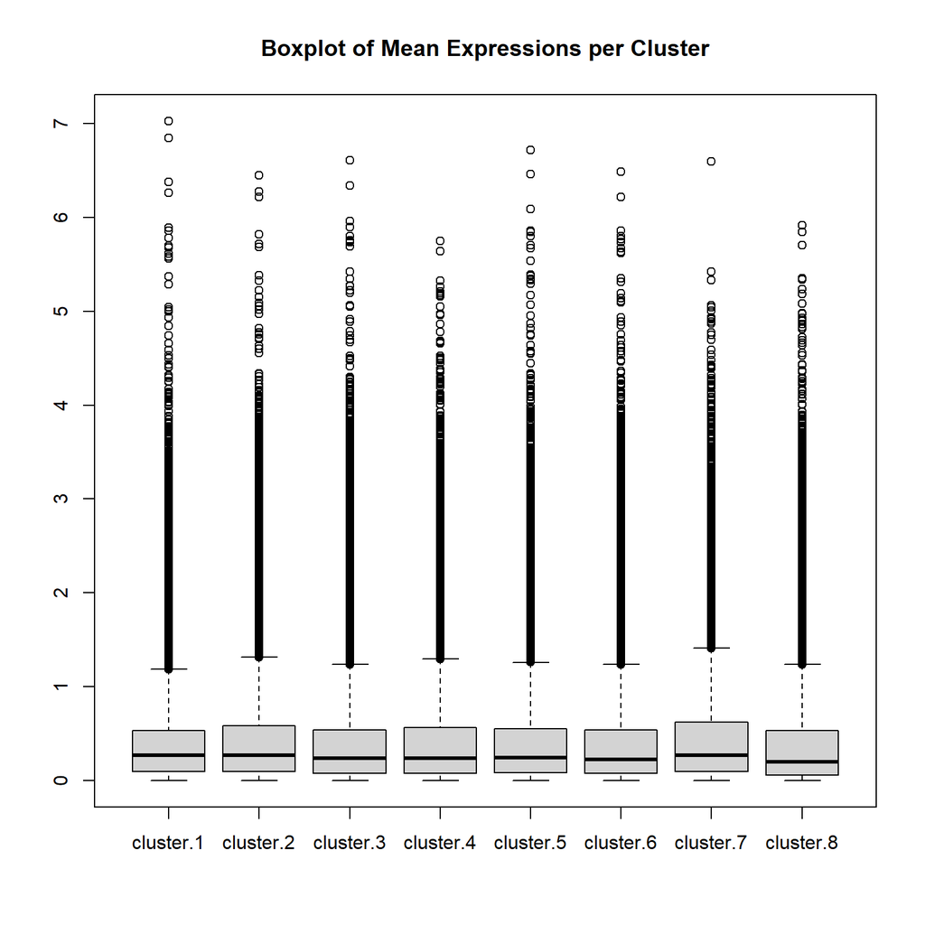

```
## [1] "cluster.1"
## [1] "cluster.2"
## [1] "cluster.3"
## [1] "cluster.4"
## [1] "cluster.5"
## [1] "cluster.6"
## [1] "cluster.7"
## [1] "cluster.8"
```

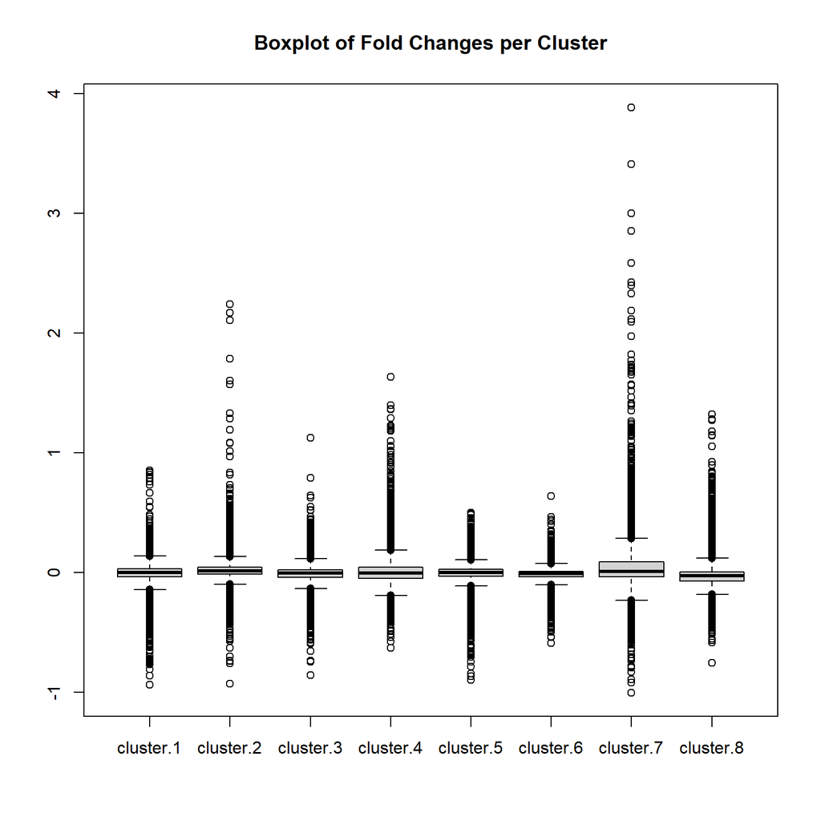

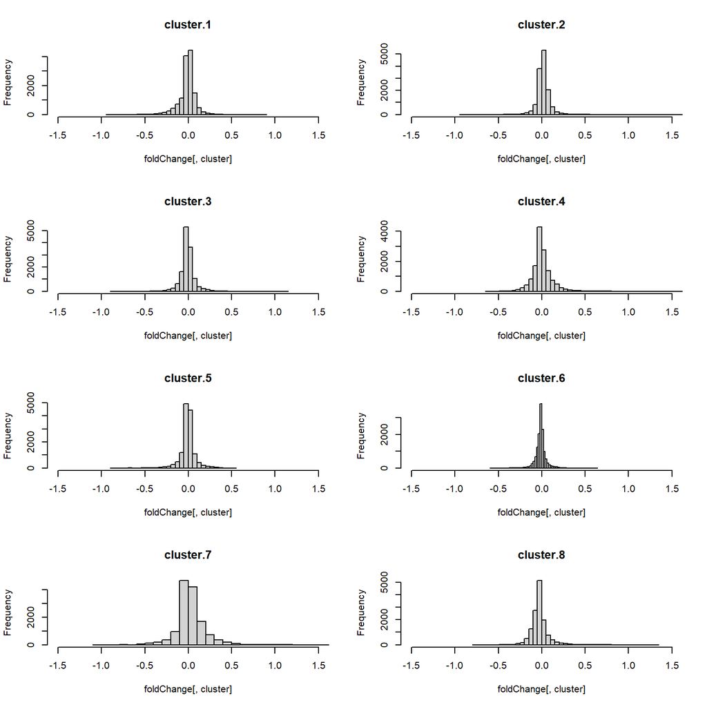

```
## [1] "The miRNA being iterated through now is mmu-miR-124-3p.1"
## [1] "topN value defined earlier was  100  and there are  1379  targets for mmu-miR-124-3p.1 in this dataset."
## [1] "The number of targets that will be used for miRNA is 100"
## [1] "cluster.1"
## [1] "The median FC of targets in cluster.1 is -0.0137638076640377"
## [1] "The median FC of non-targets in cluster.1 is -0.000227112444482289"
```

```
## [1] "cluster.2"
## [1] "The median FC of targets in cluster.2 is 0.0172476809734826"
## [1] "The median FC of non-targets in cluster.2 is 0.0114781834666731"
```

```
## [1] "cluster.3"
## [1] "The median FC of targets in cluster.3 is -0.0234753168090053"
## [1] "The median FC of non-targets in cluster.3 is -0.00487732512061452"
```

```
## [1] "cluster.4"
## [1] "The median FC of targets in cluster.4 is 0.00352181955503551"
## [1] "The median FC of non-targets in cluster.4 is -0.00324143841312872"
```

```
## [1] "cluster.5"
## [1] "The median FC of targets in cluster.5 is -0.00928129489919627"
## [1] "The median FC of non-targets in cluster.5 is -0.000907467048651483"
```

```
## [1] "cluster.6"
## [1] "The median FC of targets in cluster.6 is -0.0227739313382312"
## [1] "The median FC of non-targets in cluster.6 is -0.00814131971567739"
```

```
## [1] "cluster.7"
## [1] "The median FC of targets in cluster.7 is 0.0195254709783133"
## [1] "The median FC of non-targets in cluster.7 is 0.0096472716154441"
```

```
## [1] "cluster.8"
## [1] "The median FC of targets in cluster.8 is -0.00570304488693953"
## [1] "The median FC of non-targets in cluster.8 is -0.0261752058260613"
```

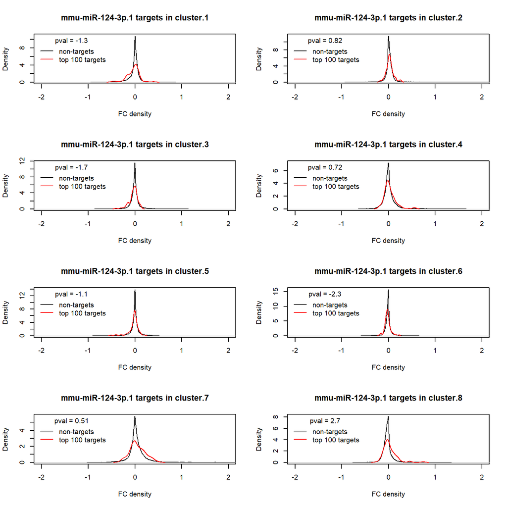

```
## [1] "The miRNA being iterated through now is mmu-miR-9-5p"
## [1] "topN value defined earlier was  100  and there are  1017  targets for mmu-miR-9-5p in this dataset."
## [1] "The number of targets that will be used for miRNA is 100"
## [1] "cluster.1"
## [1] "The median FC of targets in cluster.1 is -0.00335418275143805"
## [1] "The median FC of non-targets in cluster.1 is -0.000227112444482289"
```

```
## [1] "cluster.2"
## [1] "The median FC of targets in cluster.2 is 0.019529778621401"
## [1] "The median FC of non-targets in cluster.2 is 0.0115488855242195"
```

```
## [1] "cluster.3"
## [1] "The median FC of targets in cluster.3 is -0.0205748927843401"
## [1] "The median FC of non-targets in cluster.3 is -0.00485665746209407"
```

```
## [1] "cluster.4"
## [1] "The median FC of targets in cluster.4 is -0.000215733064433137"
## [1] "The median FC of non-targets in cluster.4 is -0.00330070085980926"
```

```
## [1] "cluster.5"
## [1] "The median FC of targets in cluster.5 is -0.00867144333946205"
## [1] "The median FC of non-targets in cluster.5 is -0.000907467048651483"
```

```
## [1] "cluster.6"
## [1] "The median FC of targets in cluster.6 is -0.012611357840617"
## [1] "The median FC of non-targets in cluster.6 is -0.00819175537018985"
```

```
## [1] "cluster.7"
## [1] "The median FC of targets in cluster.7 is 0.0110939399940371"
## [1] "The median FC of non-targets in cluster.7 is 0.00972347972687021"
```

```
## [1] "cluster.8"
## [1] "The median FC of targets in cluster.8 is -0.00929311754727337"
## [1] "The median FC of non-targets in cluster.8 is -0.0261731902690392"
```

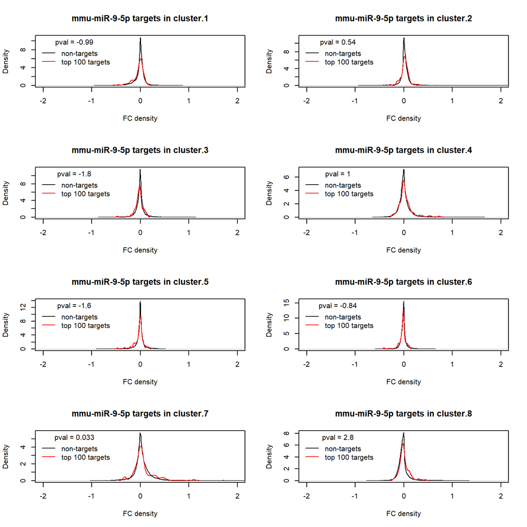

```
## [1] "The miRNA being iterated through now is mmu-miR-122-5p"
## [1] "topN value defined earlier was  100  and there are  180  targets for mmu-miR-122-5p in this dataset."
## [1] "The number of targets that will be used for miRNA is 100"
## [1] "cluster.1"
## [1] "The median FC of targets in cluster.1 is 0.00152201283334841"
## [1] "The median FC of non-targets in cluster.1 is -0.000227112444482289"
```

```
## [1] "cluster.2"
## [1] "The median FC of targets in cluster.2 is 0.0100689190160305"
## [1] "The median FC of non-targets in cluster.2 is 0.0115866676351272"
```

```
## [1] "cluster.3"
## [1] "The median FC of targets in cluster.3 is -0.0123363151765175"
## [1] "The median FC of non-targets in cluster.3 is -0.00490367187232732"
```

```
## [1] "cluster.4"
## [1] "The median FC of targets in cluster.4 is -0.0114986927168504"
## [1] "The median FC of non-targets in cluster.4 is -0.00314130279807216"
```

```
## [1] "cluster.5"
## [1] "The median FC of targets in cluster.5 is -0.00330070085980926"
## [1] "The median FC of non-targets in cluster.5 is -0.000907467048651483"
```

```
## [1] "cluster.6"
## [1] "The median FC of targets in cluster.6 is -0.0097465292906969"
## [1] "The median FC of non-targets in cluster.6 is -0.0082233067566157"
```

```
## [1] "cluster.7"
## [1] "The median FC of targets in cluster.7 is 0.0230892656871635"
## [1] "The median FC of non-targets in cluster.7 is 0.00954452171665798"
```

```
## [1] "cluster.8"
## [1] "The median FC of targets in cluster.8 is -0.019426327250749"
## [1] "The median FC of non-targets in cluster.8 is -0.0261580989026671"
```

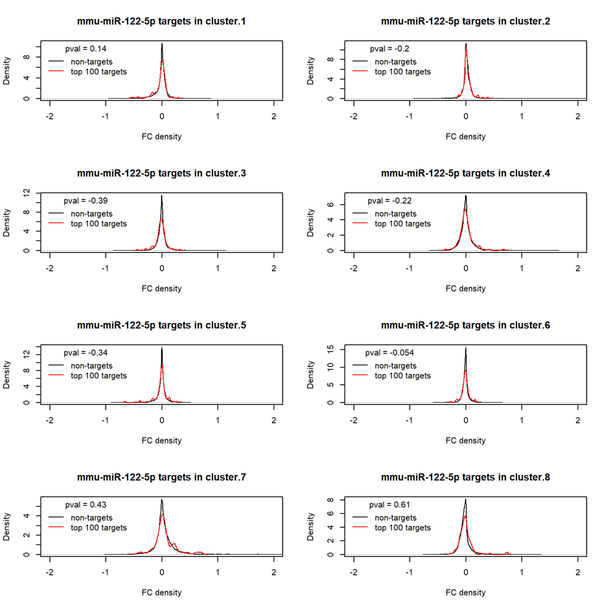

```
## [1] "The miRNA being iterated through now is mmu-miR-1a-3p"
## [1] "topN value defined earlier was  100  and there are  634  targets for mmu-miR-1a-3p in this dataset."
## [1] "The number of targets that will be used for miRNA is 100"
## [1] "cluster.1"
## [1] "The median FC of targets in cluster.1 is -0.041302663963157"
## [1] "The median FC of non-targets in cluster.1 is -0.000227112444482289"
```

```
## [1] "cluster.2"
## [1] "The median FC of targets in cluster.2 is 0.0169566782234712"
## [1] "The median FC of non-targets in cluster.2 is 0.0115491067366672"
```

```
## [1] "cluster.3"
## [1] "The median FC of targets in cluster.3 is -0.0366212272365242"
## [1] "The median FC of non-targets in cluster.3 is -0.00479681073473553"
```

```
## [1] "cluster.4"
## [1] "The median FC of targets in cluster.4 is 0.0278767051294934"
## [1] "The median FC of non-targets in cluster.4 is -0.00330070085980926"
```

```
## [1] "cluster.5"
## [1] "The median FC of targets in cluster.5 is -0.0298247222699866"
## [1] "The median FC of non-targets in cluster.5 is -0.000884116301734624"
```

```
## [1] "cluster.6"
## [1] "The median FC of targets in cluster.6 is -0.032644995426504"
## [1] "The median FC of non-targets in cluster.6 is -0.00812377661175068"
```

```
## [1] "cluster.7"
## [1] "The median FC of targets in cluster.7 is 0.0760091130080545"
## [1] "The median FC of non-targets in cluster.7 is 0.00947907426648151"
```

```
## [1] "cluster.8"
## [1] "The median FC of targets in cluster.8 is -0.0033107727724862"
## [1] "The median FC of non-targets in cluster.8 is -0.0262018844697681"
```

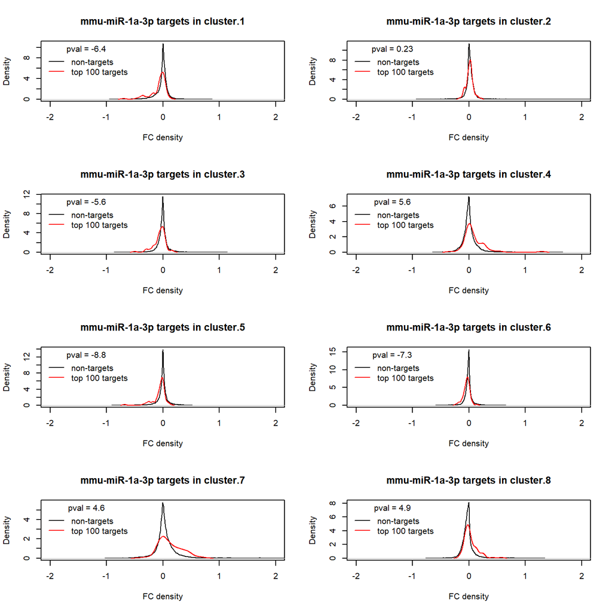

```
## [1] "The miRNA being iterated through now is mmu-miR-133a-3p.1"
## [1] "topN value defined earlier was  100  and there are  408  targets for mmu-miR-133a-3p.1 in this dataset."
## [1] "The number of targets that will be used for miRNA is 100"
## [1] "cluster.1"
## [1] "The median FC of targets in cluster.1 is -0.00606963086397547"
## [1] "The median FC of non-targets in cluster.1 is -0.000227112444482289"
```

```
## [1] "cluster.2"
## [1] "The median FC of targets in cluster.2 is 0.00459304325012765"
## [1] "The median FC of non-targets in cluster.2 is 0.0116116235477055"
```

```
## [1] "cluster.3"
## [1] "The median FC of targets in cluster.3 is -0.0229413465296548"
## [1] "The median FC of non-targets in cluster.3 is -0.00483846754063831"
```

```
## [1] "cluster.4"
## [1] "The median FC of targets in cluster.4 is -0.00235097058453322"
## [1] "The median FC of non-targets in cluster.4 is -0.00323075221412999"
```

```
## [1] "cluster.5"
## [1] "The median FC of targets in cluster.5 is -0.0091367538599632"
## [1] "The median FC of non-targets in cluster.5 is -0.000884116301734624"
```

```
## [1] "cluster.6"
## [1] "The median FC of targets in cluster.6 is -0.0147241293455667"
## [1] "The median FC of non-targets in cluster.6 is -0.0081711929754715"
```

```
## [1] "cluster.7"
## [1] "The median FC of targets in cluster.7 is 0.0546663949901332"
## [1] "The median FC of non-targets in cluster.7 is 0.00945911508751671"
```

```
## [1] "cluster.8"
## [1] "The median FC of targets in cluster.8 is -0.0136680464034139"
## [1] "The median FC of non-targets in cluster.8 is -0.0261731902690392"
```

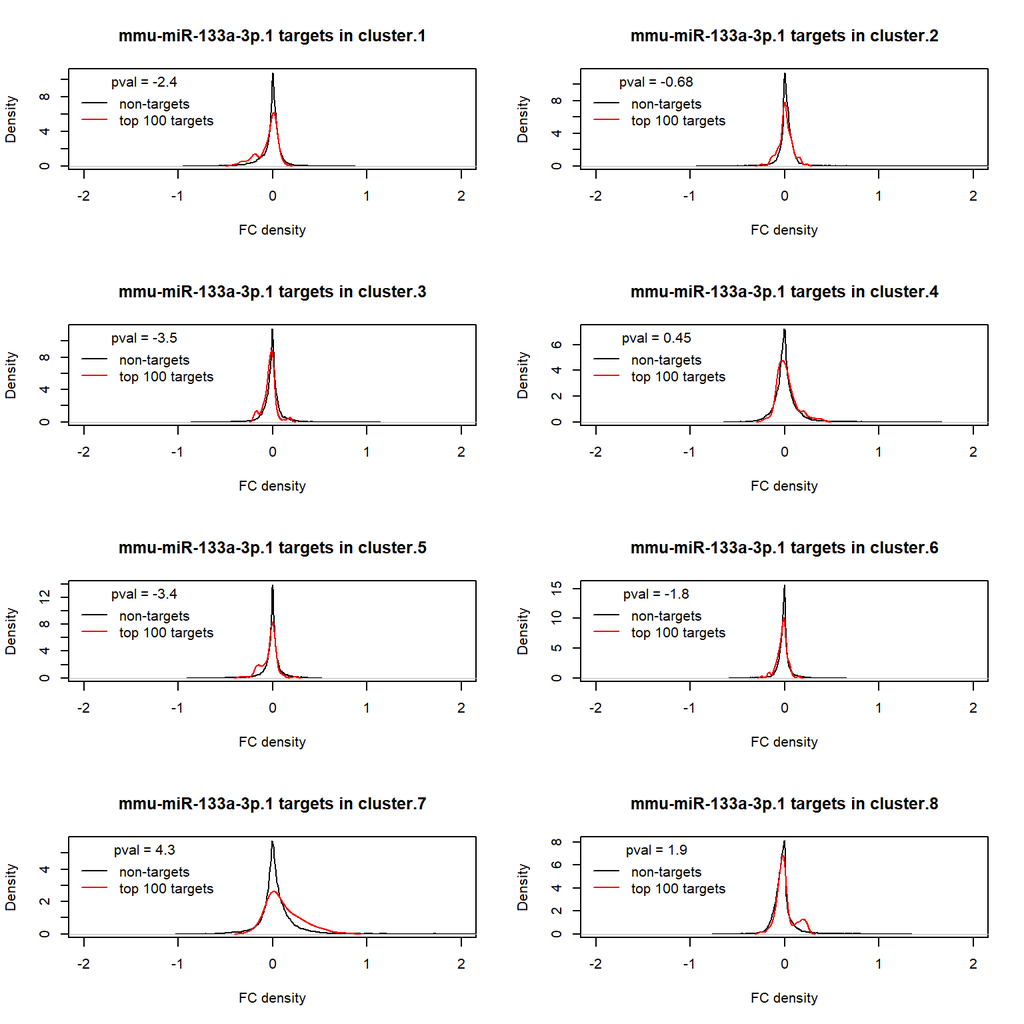

```
## [1] "The miRNA being iterated through now is mmu-let-7a-5p"
## [1] "topN value defined earlier was  100  and there are  857  targets for mmu-let-7a-5p in this dataset."
## [1] "The number of targets that will be used for miRNA is 100"
## [1] "cluster.1"
## [1] "The median FC of targets in cluster.1 is 0.0178429138885876"
## [1] "The median FC of non-targets in cluster.1 is -0.000227112444482289"
```

```
## [1] "cluster.2"
## [1] "The median FC of targets in cluster.2 is 0.00792166539863767"
## [1] "The median FC of non-targets in cluster.2 is 0.0115983748391252"
```

```
## [1] "cluster.3"
## [1] "The median FC of targets in cluster.3 is -0.00459012915960712"
## [1] "The median FC of non-targets in cluster.3 is -0.00492655675742891"
```

```
## [1] "cluster.4"
## [1] "The median FC of targets in cluster.4 is -0.000894052832640561"
## [1] "The median FC of non-targets in cluster.4 is -0.00323975326156521"
```

```
## [1] "cluster.5"
## [1] "The median FC of targets in cluster.5 is -0.00250243467544821"
## [1] "The median FC of non-targets in cluster.5 is -0.000925430147610074"
```

```
## [1] "cluster.6"
## [1] "The median FC of targets in cluster.6 is -0.00627677285165895"
## [1] "The median FC of non-targets in cluster.6 is -0.00824771241270589"
```

```
## [1] "cluster.7"
## [1] "The median FC of targets in cluster.7 is 0.0146083068527015"
## [1] "The median FC of non-targets in cluster.7 is 0.00960673206103928"
```

```
## [1] "cluster.8"
## [1] "The median FC of targets in cluster.8 is -0.0354664893409852"
## [1] "The median FC of non-targets in cluster.8 is -0.0260320066583671"
```

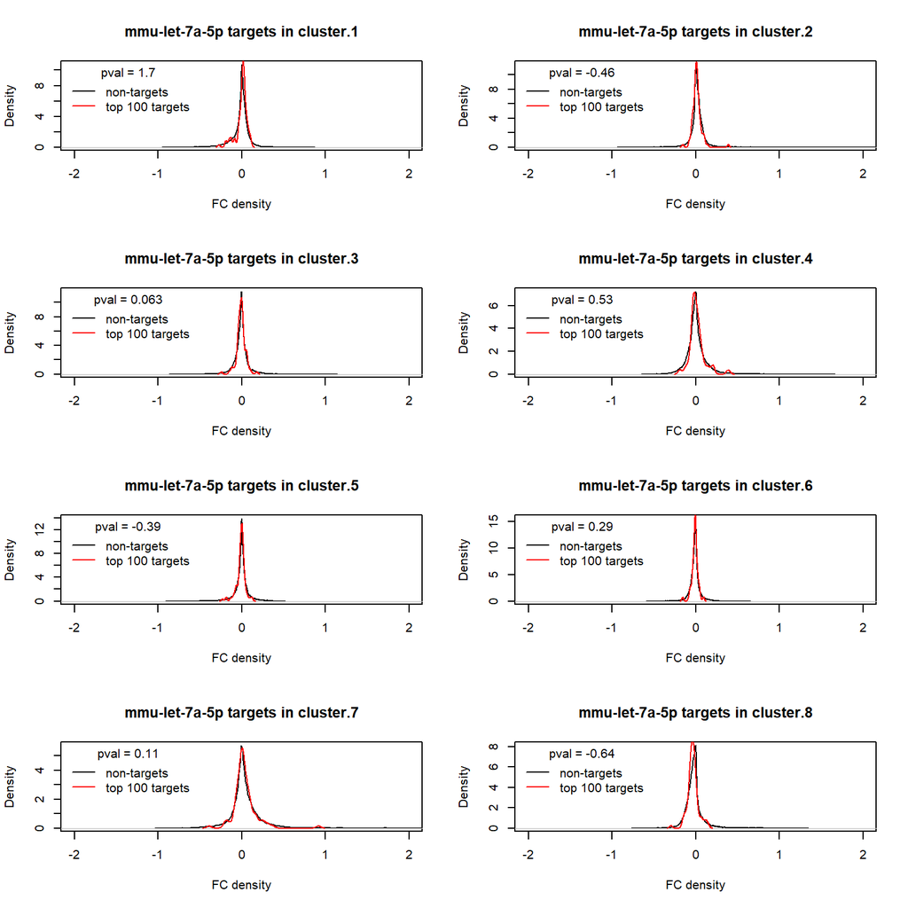

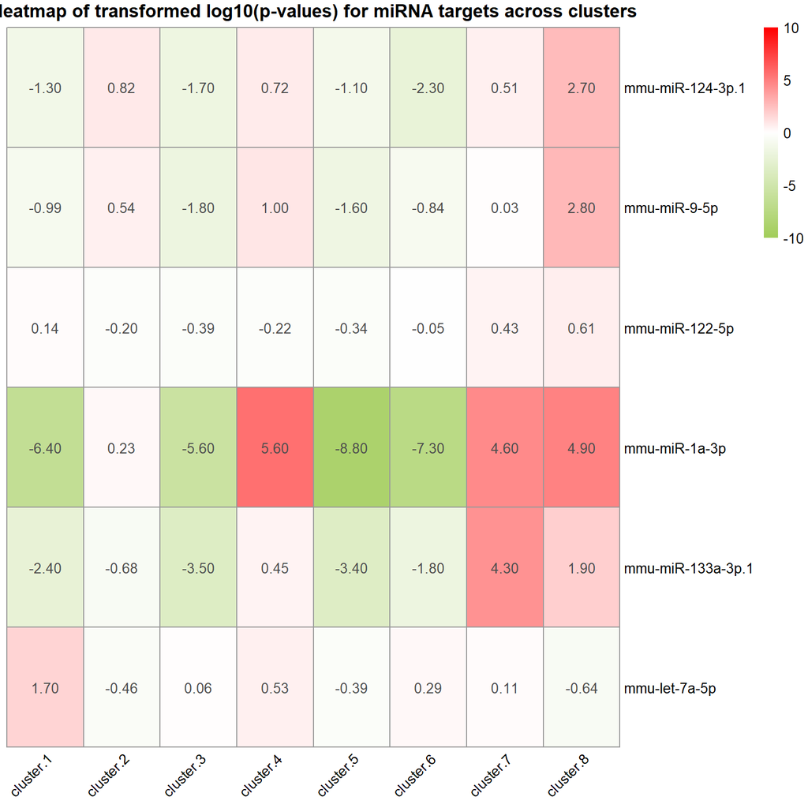

```r
# Enter the name of the subscript that you want to be used to generate the heatmap
# This change applies globally

Script_name_Heatmap <- "SPATA2_V3_Signed_Heatmap_all_clusters.R"

source(Script_name_Heatmap)
```

## Now with bayes and scaled

```r
# This iteration: bayes & scaled
expTab <- expTabScaled
cluTab <- cluTab_bayesspaces


all(colnames(expTab) %in% rownames(cluTab))
```

```
## [1] TRUE
```

```r
# Calculate average expression per-cluster
table(cluTab$bayes_space)
```

```
##
##   1   2   3   4   5   6   7   8
## 187  38 298  37 555  30 115 114
```

```r
# Transform clusters to names, keeping integers for names is a bad idea in R
cluTab$clusters <- paste0("cluster.", cluTab$bayes_space)

table(cluTab$clusters)
```

```
##
## cluster.1 cluster.2 cluster.3 cluster.4 cluster.5 cluster.6 cluster.7 cluster.8
##       187        38       298        37       555        30       115       114
```

```r
# set mfrow value according to predefined function
num_clusters <- length(unique(cluTab$clusters))
mfrow_setting <- set_mfrow_setting(num_clusters)
print(paste0("The number of clusters were ", num_clusters, " so mfrow value in par() was set accordingly"))
```

```
## [1] "The number of clusters were 8 so mfrow value in par() was set accordingly"
```

```r
# usage
num_clusters <- length(unique(cluTab$clusters))
mfrow_setting <- set_mfrow_setting(num_clusters)
print(paste0("The number of clusters were ", num_clusters, " so mfrow value in par() was set accordingly"))
```

```
## [1] "The number of clusters were 8 so mfrow value in par() was set accordingly"
```

```
## [1] "There are 4302 missing targets for the chosen miRNAs in the dataset of size 13681"
## [1] "Average for cluster: cluster.1"
## [1] "Average for cluster: cluster.2"
## [1] "Average for cluster: cluster.3"
## [1] "Average for cluster: cluster.4"
## [1] "Average for cluster: cluster.5"
## [1] "Average for cluster: cluster.6"
## [1] "Average for cluster: cluster.7"
## [1] "Average for cluster: cluster.8"
```

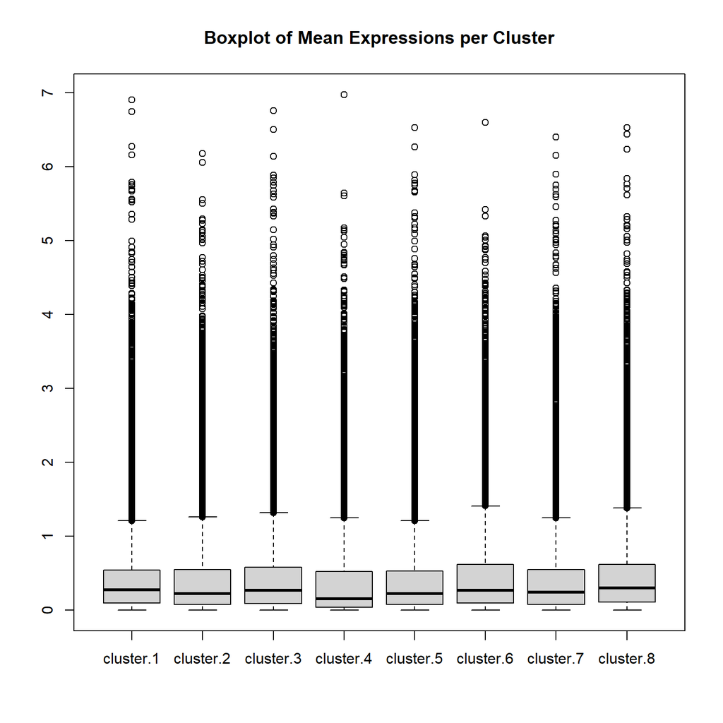

```
## [1] "cluster.1"
## [1] "cluster.2"
## [1] "cluster.3"
## [1] "cluster.4"
## [1] "cluster.5"
## [1] "cluster.6"
## [1] "cluster.7"
## [1] "cluster.8"
```

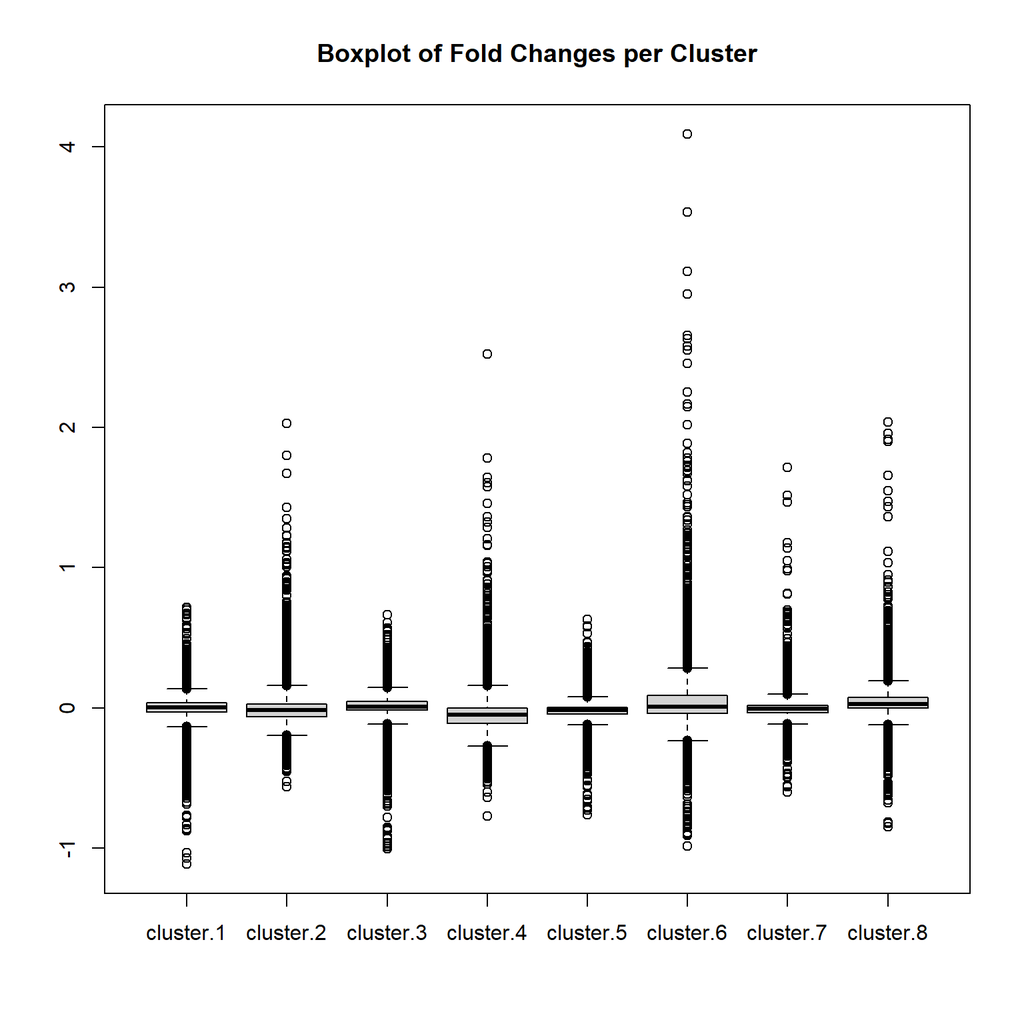

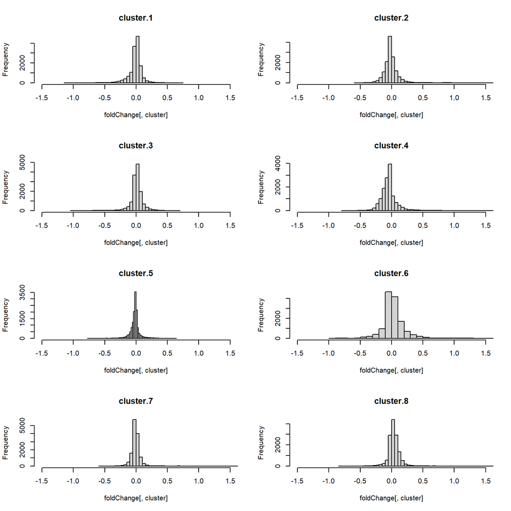

```
## [1] "The miRNA being iterated through now is mmu-miR-124-3p.1"
## [1] "topN value defined earlier was  100  and there are  1379  targets for mmu-miR-124-3p.1 in this dataset."
## [1] "The number of targets that will be used for miRNA is 100"
## [1] "cluster.1"
## [1] "The median FC of targets in cluster.1 is -0.00542457581944678"
## [1] "The median FC of non-targets in cluster.1 is 0.00362468917874502"
```

```
## [1] "cluster.2"
## [1] "The median FC of targets in cluster.2 is -0.00627396693619619"
## [1] "The median FC of non-targets in cluster.2 is -0.0132414844143435"
```

```
## [1] "cluster.3"
## [1] "The median FC of targets in cluster.3 is 0.000403391773364525"
## [1] "The median FC of non-targets in cluster.3 is 0.00962802929219783"
```

```
## [1] "cluster.4"
## [1] "The median FC of targets in cluster.4 is -0.0474909526011008"
## [1] "The median FC of non-targets in cluster.4 is -0.0471025410687501"
```

```
## [1] "cluster.5"
## [1] "The median FC of targets in cluster.5 is -0.03360348475566"
## [1] "The median FC of non-targets in cluster.5 is -0.0124344319146619"
```

```
## [1] "cluster.6"
## [1] "The median FC of targets in cluster.6 is 0.00964864317150385"
## [1] "The median FC of non-targets in cluster.6 is 0.00910215398797508"
```

```
## [1] "cluster.7"
## [1] "The median FC of targets in cluster.7 is -0.0129115911660013"
## [1] "The median FC of non-targets in cluster.7 is -0.00385614353304915"
```

```
## [1] "cluster.8"
## [1] "The median FC of targets in cluster.8 is 0.0486218396875663"
## [1] "The median FC of non-targets in cluster.8 is 0.0296289267406504"
```

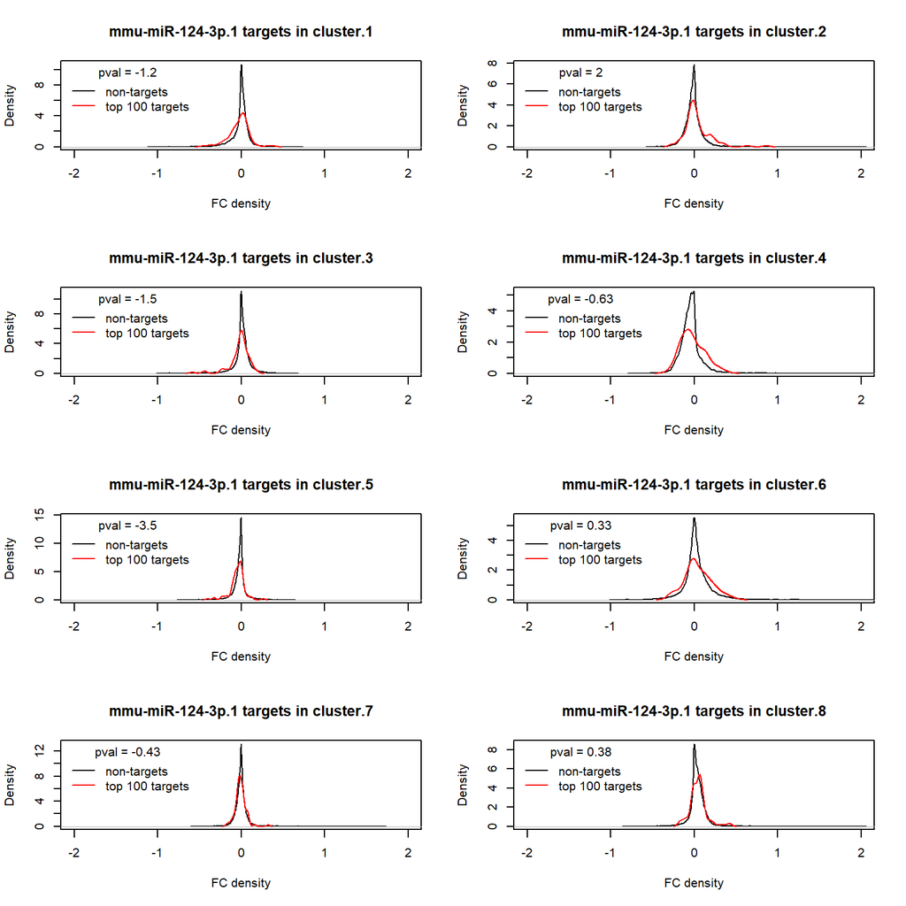

```
## [1] "The miRNA being iterated through now is mmu-miR-9-5p"
## [1] "topN value defined earlier was  100  and there are  1017  targets for mmu-miR-9-5p in this dataset."
## [1] "The number of targets that will be used for miRNA is 100"
## [1] "cluster.1"
## [1] "The median FC of targets in cluster.1 is -0.000332285321457308"
## [1] "The median FC of non-targets in cluster.1 is 0.00363894047080573"
```

```
## [1] "cluster.2"
## [1] "The median FC of targets in cluster.2 is -0.000178416262692393"
## [1] "The median FC of non-targets in cluster.2 is -0.0133544510928401"
```

```
## [1] "cluster.3"
## [1] "The median FC of targets in cluster.3 is -0.00212945829587812"
## [1] "The median FC of non-targets in cluster.3 is 0.00971871892107132"
```

```
## [1] "cluster.4"
## [1] "The median FC of targets in cluster.4 is -0.0360722409119216"
## [1] "The median FC of non-targets in cluster.4 is -0.0472653257224573"
```

```
## [1] "cluster.5"
## [1] "The median FC of targets in cluster.5 is -0.0227504578473213"
## [1] "The median FC of non-targets in cluster.5 is -0.0124613991009054"
```

```
## [1] "cluster.6"
## [1] "The median FC of targets in cluster.6 is 0.00616723129944717"
## [1] "The median FC of non-targets in cluster.6 is 0.0091325142935208"
```

```
## [1] "cluster.7"
## [1] "The median FC of targets in cluster.7 is -0.00528385620240399"
## [1] "The median FC of non-targets in cluster.7 is -0.00387149220731711"
```

```
## [1] "cluster.8"
## [1] "The median FC of targets in cluster.8 is 0.0293474152688554"
## [1] "The median FC of non-targets in cluster.8 is 0.0296774524720055"
```

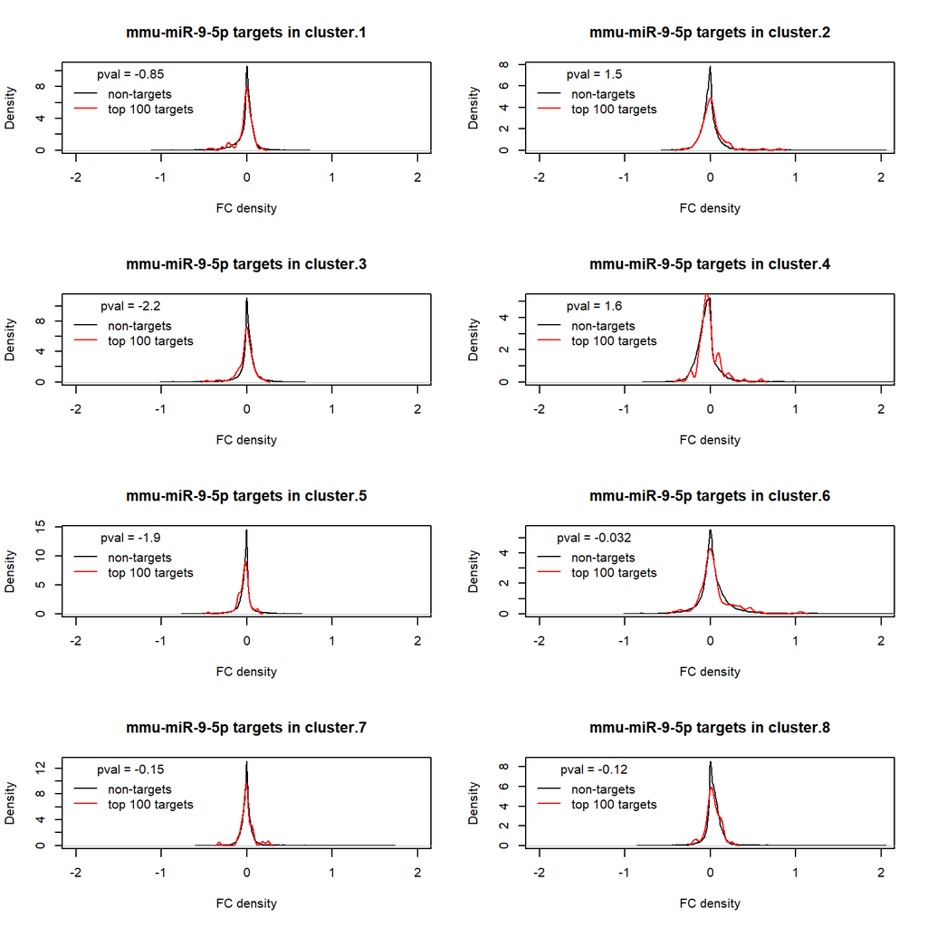

```
## [1] "The miRNA being iterated through now is mmu-miR-122-5p"
## [1] "topN value defined earlier was  100  and there are  180  targets for mmu-miR-122-5p in this dataset."
## [1] "The number of targets that will be used for miRNA is 100"
## [1] "cluster.1"
## [1] "The median FC of targets in cluster.1 is -0.00254437684236832"
## [1] "The median FC of non-targets in cluster.1 is 0.00359930938967749"
```

```
## [1] "cluster.2"
## [1] "The median FC of targets in cluster.2 is -0.00452119411142603"
## [1] "The median FC of non-targets in cluster.2 is -0.0132414844143435"
```

```
## [1] "cluster.3"
## [1] "The median FC of targets in cluster.3 is 0.00511631409546722"
## [1] "The median FC of non-targets in cluster.3 is 0.00958863677682988"
```

```
## [1] "cluster.4"
## [1] "The median FC of targets in cluster.4 is -0.0387566627662153"
## [1] "The median FC of non-targets in cluster.4 is -0.0471557025270425"
```

```
## [1] "cluster.5"
## [1] "The median FC of targets in cluster.5 is -0.0202009802130154"
## [1] "The median FC of non-targets in cluster.5 is -0.0125200032984538"
```

```
## [1] "cluster.6"
## [1] "The median FC of targets in cluster.6 is 0.0176738302907967"
## [1] "The median FC of non-targets in cluster.6 is 0.00900629434187683"
```

```
## [1] "cluster.7"
## [1] "The median FC of targets in cluster.7 is -0.00330070085980926"
## [1] "The median FC of non-targets in cluster.7 is -0.00387314668374744"
```

```
## [1] "cluster.8"
## [1] "The median FC of targets in cluster.8 is 0.0320623959258948"
## [1] "The median FC of non-targets in cluster.8 is 0.0296715138724452"
```

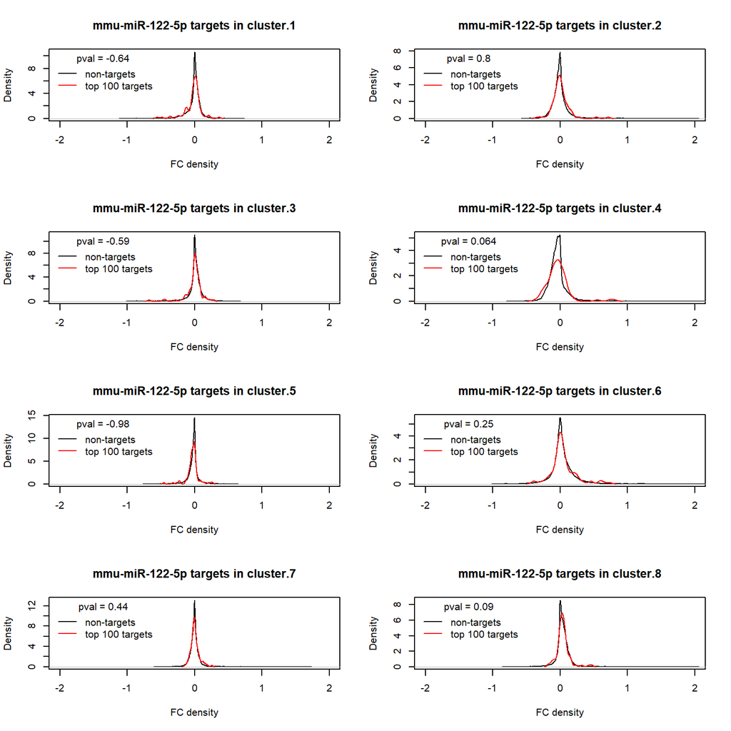

```
## [1] "The miRNA being iterated through now is mmu-miR-1a-3p"
## [1] "topN value defined earlier was  100  and there are  634  targets for mmu-miR-1a-3p in this dataset."
## [1] "The number of targets that will be used for miRNA is 100"
## [1] "cluster.1"
## [1] "The median FC of targets in cluster.1 is -0.0220489947508939"
## [1] "The median FC of non-targets in cluster.1 is 0.00370666941475907"
```

```
## [1] "cluster.2"
## [1] "The median FC of targets in cluster.2 is 0.0196862245769428"
## [1] "The median FC of non-targets in cluster.2 is -0.0134630931621752"
```

```
## [1] "cluster.3"
## [1] "The median FC of targets in cluster.3 is -0.0148755066463356"
## [1] "The median FC of non-targets in cluster.3 is 0.00978466265681124"
```

```
## [1] "cluster.4"
## [1] "The median FC of targets in cluster.4 is -0.0369603790302653"
## [1] "The median FC of non-targets in cluster.4 is -0.0472007838072569"
```

```
## [1] "cluster.5"
## [1] "The median FC of targets in cluster.5 is -0.0497631115980031"
## [1] "The median FC of non-targets in cluster.5 is -0.0123728198702573"
```

```
## [1] "cluster.6"
## [1] "The median FC of targets in cluster.6 is 0.0701575961497888"
## [1] "The median FC of non-targets in cluster.6 is 0.00887966655385011"
```

```
## [1] "cluster.7"
## [1] "The median FC of targets in cluster.7 is -0.0136017538648476"
## [1] "The median FC of non-targets in cluster.7 is -0.00383172698949436"
```

```
## [1] "cluster.8"
## [1] "The median FC of targets in cluster.8 is 0.0377627100888034"
## [1] "The median FC of non-targets in cluster.8 is 0.0296485595607496"
```

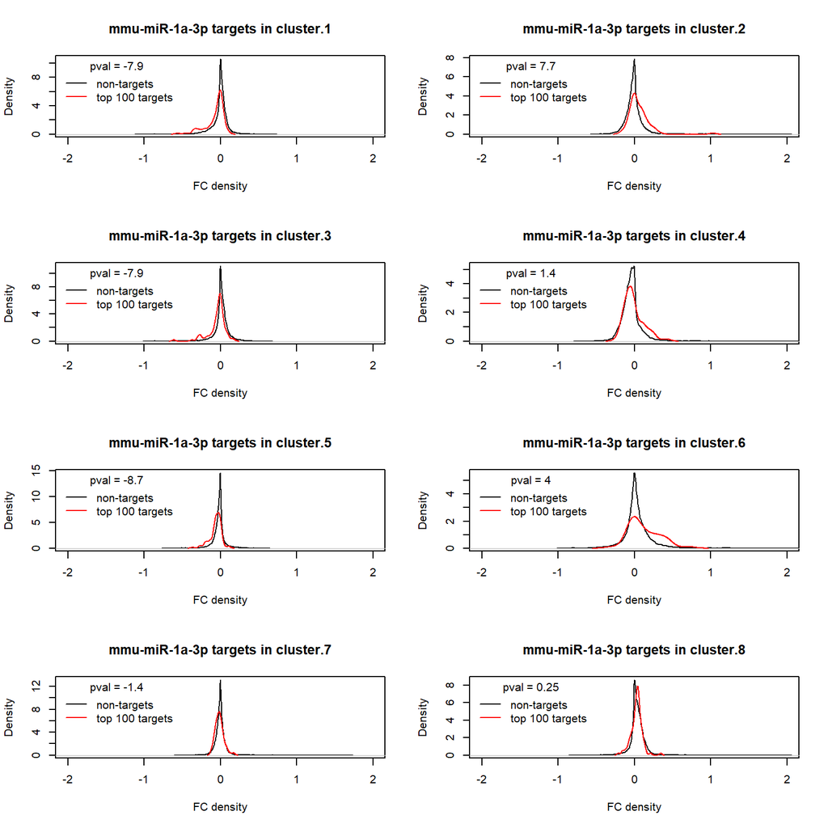

```
## [1] "The miRNA being iterated through now is mmu-miR-133a-3p.1"
## [1] "topN value defined earlier was  100  and there are  408  targets for mmu-miR-133a-3p.1 in this dataset."
## [1] "The number of targets that will be used for miRNA is 100"
## [1] "cluster.1"
## [1] "The median FC of targets in cluster.1 is -0.00175451814263534"
## [1] "The median FC of non-targets in cluster.1 is 0.00359930938967749"
```

```
## [1] "cluster.2"
## [1] "The median FC of targets in cluster.2 is 0.000504834934148399"
## [1] "The median FC of non-targets in cluster.2 is -0.0134315502841098"
```

```
## [1] "cluster.3"
## [1] "The median FC of targets in cluster.3 is -0.00129275813064414"
## [1] "The median FC of non-targets in cluster.3 is 0.00973189381843942"
```

```
## [1] "cluster.4"
## [1] "The median FC of targets in cluster.4 is -0.046704303976961"
## [1] "The median FC of non-targets in cluster.4 is -0.0471220540103858"
```

```
## [1] "cluster.5"
## [1] "The median FC of targets in cluster.5 is -0.0306969217040656"
## [1] "The median FC of non-targets in cluster.5 is -0.0123935396779502"
```

```
## [1] "cluster.6"
## [1] "The median FC of targets in cluster.6 is 0.0462098120373297"
## [1] "The median FC of non-targets in cluster.6 is 0.00885476161969878"
```

```
## [1] "cluster.7"
## [1] "The median FC of targets in cluster.7 is -0.00705503790483907"
## [1] "The median FC of non-targets in cluster.7 is -0.00387149220731711"
```

```
## [1] "cluster.8"
## [1] "The median FC of targets in cluster.8 is 0.0150870247148758"
## [1] "The median FC of non-targets in cluster.8 is 0.0297487585480364"
```

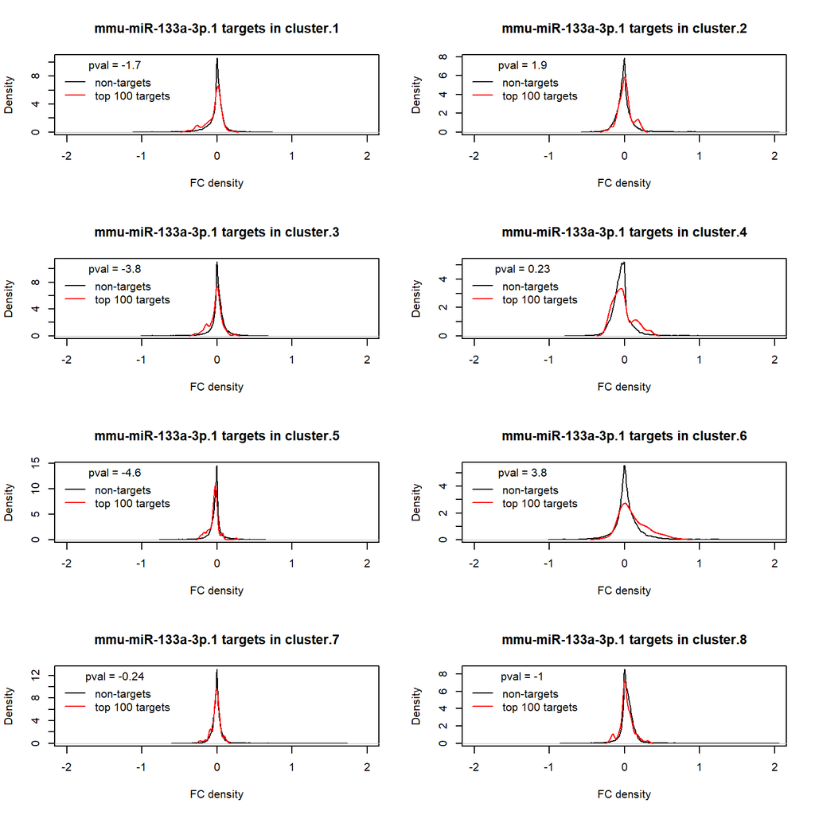

```
## [1] "The miRNA being iterated through now is mmu-let-7a-5p"
## [1] "topN value defined earlier was  100  and there are  857  targets for mmu-let-7a-5p in this dataset."
## [1] "The number of targets that will be used for miRNA is 100"
## [1] "cluster.1"
## [1] "The median FC of targets in cluster.1 is 0.0182873274685598"
## [1] "The median FC of non-targets in cluster.1 is 0.00352825315206667"
```

```
## [1] "cluster.2"
## [1] "The median FC of targets in cluster.2 is -0.0172978852695496"
## [1] "The median FC of non-targets in cluster.2 is -0.0132028034392371"
```

```
## [1] "cluster.3"
## [1] "The median FC of targets in cluster.3 is 0.0127959599679424"
## [1] "The median FC of non-targets in cluster.3 is 0.00954082202725531"
```

```
## [1] "cluster.4"
## [1] "The median FC of targets in cluster.4 is -0.0660994615155532"
## [1] "The median FC of non-targets in cluster.4 is -0.0468683014691086"
```

```
## [1] "cluster.5"
## [1] "The median FC of targets in cluster.5 is -0.0123560558849911"
## [1] "The median FC of non-targets in cluster.5 is -0.0125659795283114"
```

```
## [1] "cluster.6"
## [1] "The median FC of targets in cluster.6 is 0.0158263529264157"
## [1] "The median FC of non-targets in cluster.6 is 0.00900176252036762"
```

```
## [1] "cluster.7"
## [1] "The median FC of targets in cluster.7 is -0.000748233199569699"
## [1] "The median FC of non-targets in cluster.7 is -0.00391869056330707"
```

```
## [1] "cluster.8"
## [1] "The median FC of targets in cluster.8 is 0.0292543248039505"
## [1] "The median FC of non-targets in cluster.8 is 0.0296774524720055"
```

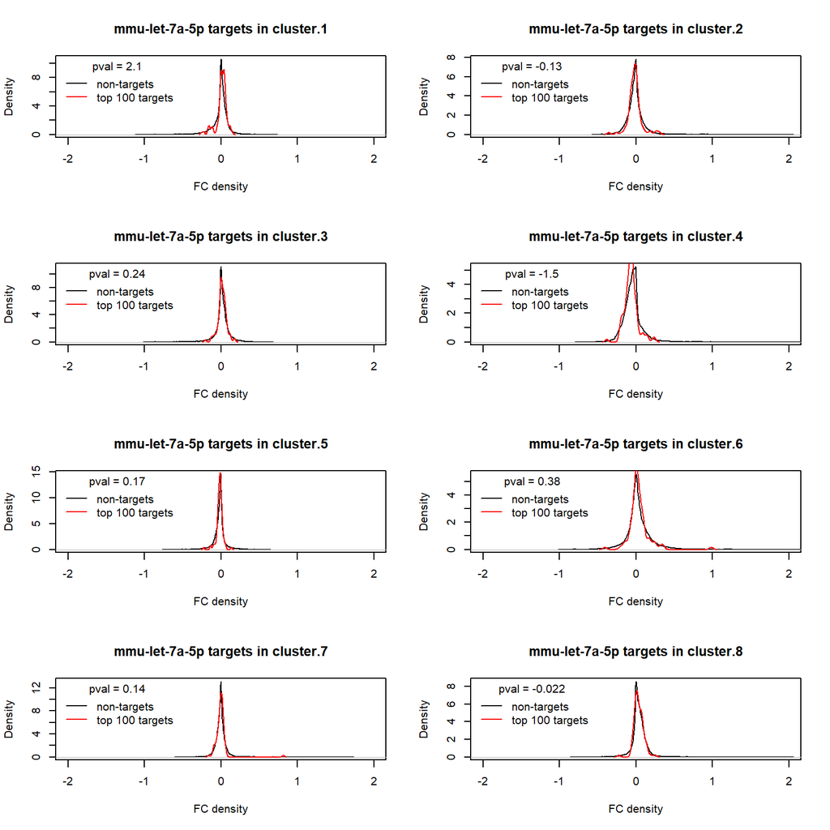

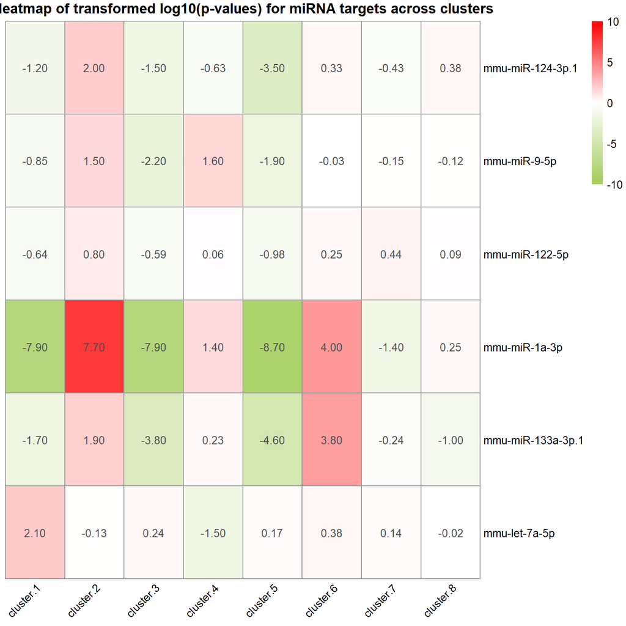

```r
source(Script_name_Heatmap)
```

## Comparison between clusters where the heatmap shows p-vals in opposite directions

This part of the script does not run automatically. This requires manual operation as the specific clusters need to be changed and varied. Remember to turn off p-value capping here so we can see how much the p-value has increased.

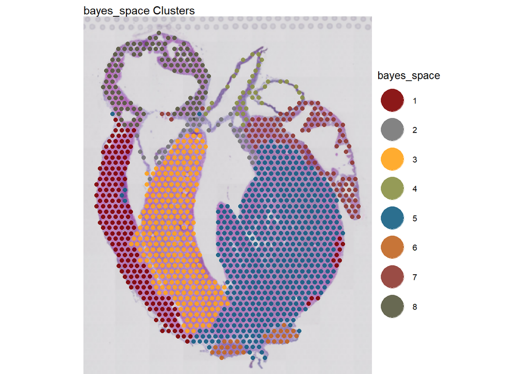

```r
# Whatever showed the best clustering results
# so we set the exp matrix and cluster tab as required
# with the heatmap that was obtained


plotSurface(
  object = main_spata2_obj_hi_res,
  color_by = "bayes_space",
  pt_clrp = "uc",
  pt_size = 2
) +
labs(subtitle = "bayes_space Clusters") +
theme(
  legend.text = element_text(size = 8),  # Adjust legend text size
  legend.title = element_text(size = 10) # Adjust legend title size
)
```

```r
# whatever shows the best clustering results
# so we set the exp matrix and cluster tab as required

# This iteration: kmeans & scaled
expTab <- expTabScaled
cluTab <- cluTab_bayesspaces

all(colnames(expTab) %in% rownames(cluTab))
```

```
## [1] TRUE
```

```r
# Calculate average expression per-cluster
table(cluTab$bayes_space)
```

```
##
##   1   2   3   4   5   6   7   8
## 187  38 298  37 555  30 115 114
```

```r
# Transform clusters to names, keeping integers for names is a bad idea in R
cluTab$clusters <- paste0("cluster.", cluTab$bayes_space)

table(cluTab$clusters)
```

```
##
## cluster.1 cluster.2 cluster.3 cluster.4 cluster.5 cluster.6 cluster.7 cluster.8
##       187        38       298        37       555        30       115       114
```

```
## [1] "There are 4302 missing targets for the chosen miRNAs in the dataset of size 13681"
## [1] "Average for cluster: cluster.1"
## [1] "Average for cluster: cluster.2"
## [1] "Average for cluster: cluster.3"
## [1] "Average for cluster: cluster.4"
## [1] "Average for cluster: cluster.5"
## [1] "Average for cluster: cluster.6"
## [1] "Average for cluster: cluster.7"
## [1] "Average for cluster: cluster.8"
## [1] "cluster.1"
## [1] "cluster.2"
## [1] "cluster.3"
## [1] "cluster.4"
## [1] "cluster.5"
## [1] "cluster.6"
```

[output cut: 164 more lines]

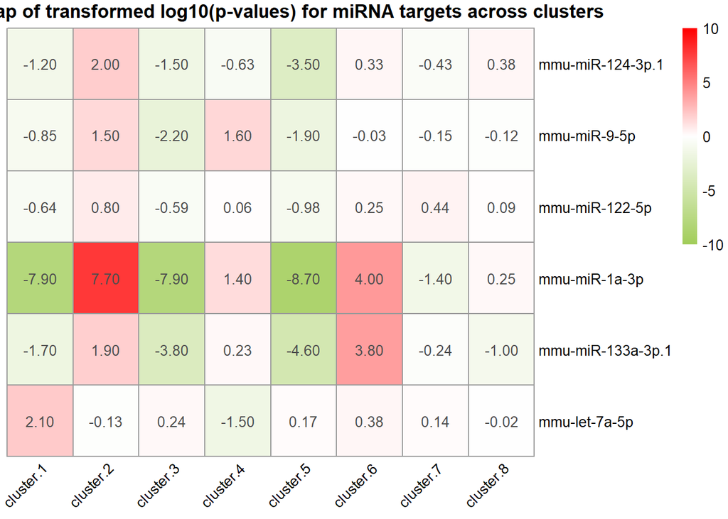

```r
# Show the heatmap again justt to confirm the right comparisons are being made
# Not needed now but do use it in the main script as bayes will also be there.
source("SPATA2_V3_Signed_Only_Heatmap_all_clusters.R")
```

```r
# this will be used later in the main Rmd file.
Script_name_comparison <- "SPATA2_V3_Signed_Heatmap_cluster_vs_cluster.R"
```

## Neighbouring Cluster vs Cluster pair comparison (can be skipped)

## Now compare two distant clusters (can be skipped)

# Compare multiple cluster pairs together and plot on the same heatmap

Remember to turn off p-value capping here so we can see how much the p-value has increased.

```r
# Compare multiple clusters together and plot on the same heatmap

# Remember to turn off p-value capping here so we can see how much the p-value has increased.

# Define cluster pairs for FC calculation
# commented out as this is given in the main rmd script to be changed globally.
cluster_pairs <- list(
  c("cluster.2", "cluster.5"),
  c("cluster.4", "cluster.2"),
  c("cluster.4", "cluster.5")
)


# Initialize p-value table
pvalTab <- data.frame(row.names = mirs)

# Checking which targets are missing from dataset
sum(!tarTab$`Gene Symbol` %in% rownames(expTab))
```

```
## [1] 0
```

```r
numMissingTar <- (length(rownames(expTab)) - (sum(rownames(expTab) %in% tarTab$`Gene Symbol`)))
print(paste("There are", numMissingTar, "missing targets for the chosen miRNAs in the dataset of size", length(rownames(expTab))))
```

```
## [1] "There are 4302 missing targets for the chosen miRNAs in the dataset of size 13681"
```

```r
# Keep only those that do have expression
tarTab <- tarTab[tarTab$`Gene Symbol` %in% rownames(expTab), ]

# Keep only those related to mouse (mmu-) miRNAs
tarTab <- tarTab[grepl("^mmu-", tarTab$miRNA), ]

# Order by weighted context++ score, if ties, then context++ score
tarTab <- tarTab[order(tarTab$`weighted context++ score`, tarTab$`context++ score`), ]

# Mean expression values for each cluster already computed earlier
head(meanExpr)
```

|  | cluster.1 | cluster.2 | cluster.3 | cluster.4 | cluster.5 | cluster.6 | cluster.7 | cluster.8 |
| --- | --- | --- | --- | --- | --- | --- | --- | --- |
| Sox17 | 0.1584782 | 0.07296286 | 0.1399551 | 0.05620112 | 0.1253158 | 0.3504997 | 0.06379945 | 0.1459257 |
| Mrpl15 | 1.0361321 | 0.91412647 | 1.0769014 | 1.00531456 | 0.9992368 | 0.8371011 | 0.96888151 | 0.9250531 |
| Lypla1 | 0.5572000 | 0.41059440 | 0.5335879 | 0.23117114 | 0.4557923 | 0.4276666 | 0.46024611 | 0.4879292 |
| Tcea1 | 0.3813020 | 0.37858399 | 0.3218691 | 0.08589335 | 0.3027125 | 0.5758855 | 0.37177599 | 0.4018817 |
| Atp6v1h | 0.2591882 | 0.31319171 | 0.2233412 | 0.17178669 | 0.2048707 | 0.1983548 | 0.21152886 | 0.2913943 |
| Rb1cc1 | 0.3472397 | 0.30872069 | 0.3744016 | 0.16719483 | 0.3183137 | 0.3640152 | 0.39394508 | 0.3983250 |

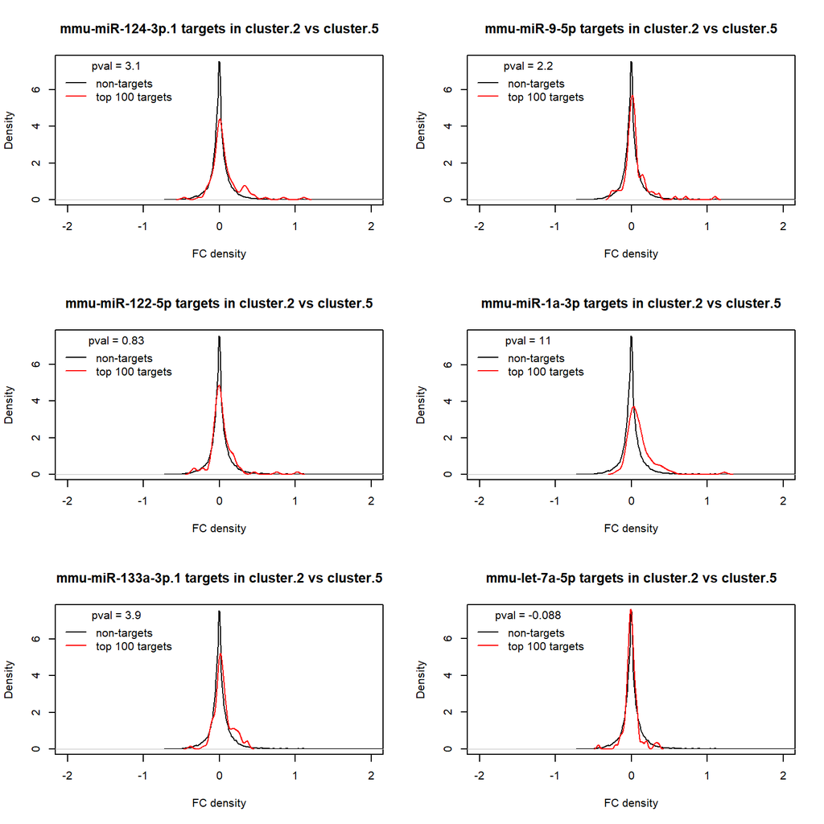

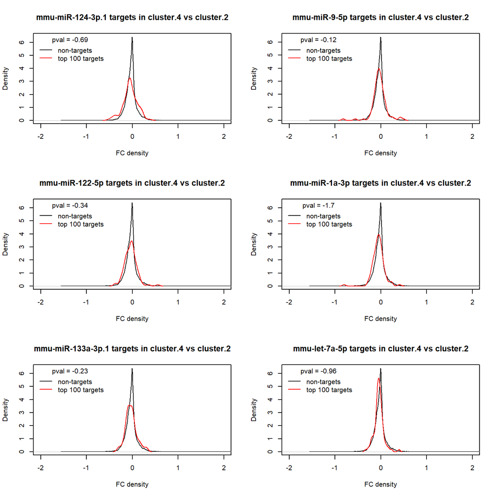

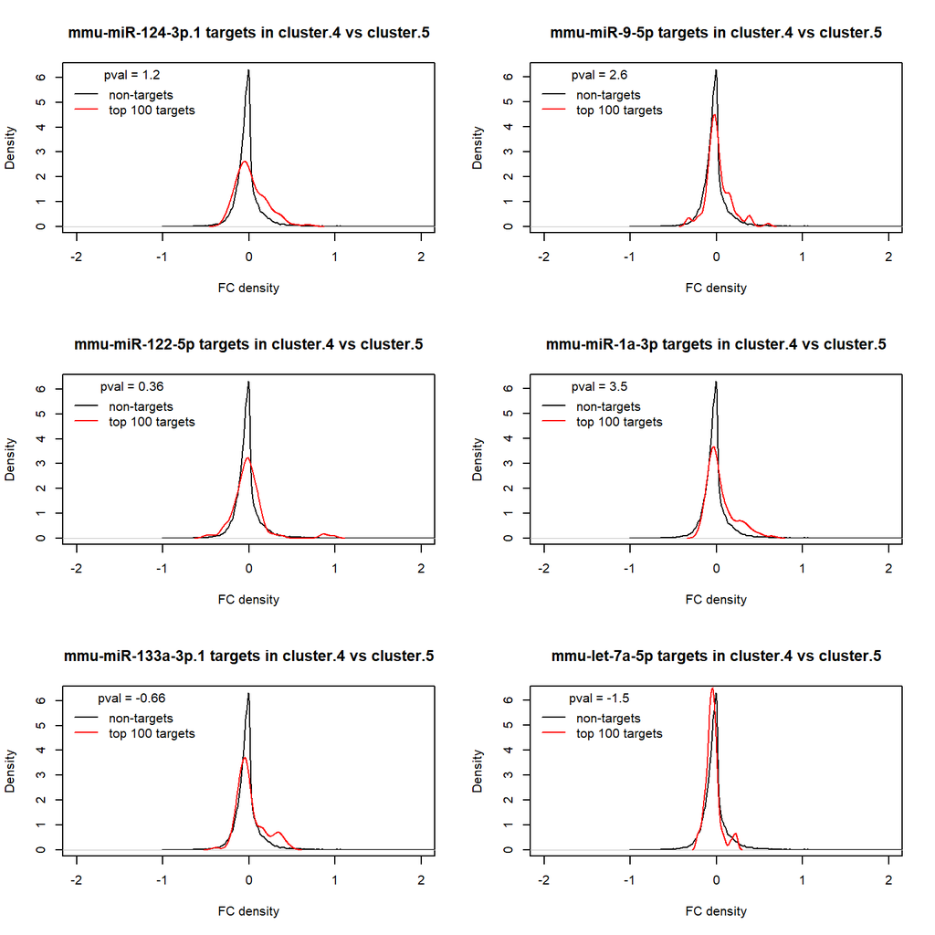

```r
# Loop through each cluster pair
for (specific_clusters in cluster_pairs) {

  # Check if specified clusters are in the mean expression data
  if (!all(specific_clusters %in% colnames(meanExpr))) {
    stop("One or more specified clusters not found in the mean expression data.")
  }

  # Calculate fold change for the specified clusters
  foldChange <- data.frame(row.names = rownames(meanExpr))
  foldChange[[paste(specific_clusters[1], "vs", specific_clusters[2])]] <- meanExpr[, specific_clusters[1]] - meanExpr[, specific_clusters[2]]

  par(mfrow=c(3,2))
  for (mir in mirs) {
    tarGenesAll <- unique(tarTab$`Gene Symbol`[tarTab$miRNA == mir])
    tarGenesTop <- tarGenesAll[seq_len(min(topN, length(tarGenesAll)))]

    x <- foldChange[tarGenesTop, 1]
    y <- foldChange[!rownames(foldChange) %in% tarGenesTop, 1]
    pval <- wilcox.test(x, y)$p.value
    pval <- log10(pval)
    pval <- signif(pval, 2) * -sign(median(x) - median(y))
    pvalTab[mir, paste(specific_clusters[1], "vs", specific_clusters[2])] <- signif(pval, 4)

    plot(density(y), xlim = c(-2, 2), xlab = "FC density", main = paste(mir, "targets in", paste(specific_clusters[1], "vs", specific_clusters[2])), col = "black")
    lines(density(x), col = 'red')
    legend("topleft", legend = c("non-targets", paste("top", length(x), "targets")), lty = 1, col = c("black", "red"), title = paste("pval =", pval), bty = "n")
  }
}
```

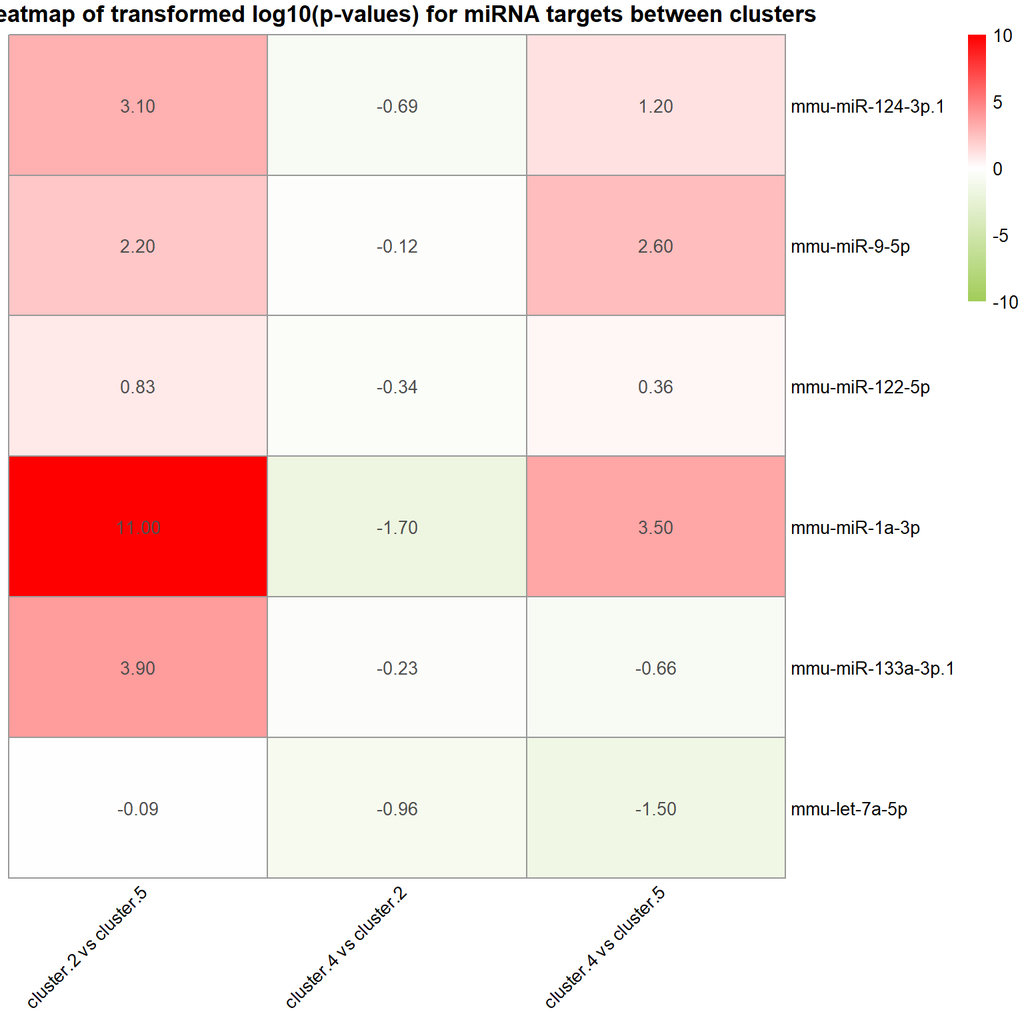

```r
# Convert the p-value data frame to a matrix
logpvalMatrix <- as.matrix.data.frame(pvalTab)

# Dont Cap values at -10 and 10, to see if it is higher.
# logpvalMatrix[logpvalMatrix > 10] <- 10
# logpvalMatrix[logpvalMatrix < -10] <- -10

# Define the breaks and color palette
breaksList <- seq(-10, 10, by = 0.1)
myColorPalette <- colorRampPalette(c("darkolivegreen3", "white", "red"))(length(breaksList) - 1)

# Generate the heatmap with the transformed values and custom number formatting
pheatmap(logpvalMatrix, cluster_rows = FALSE, cluster_cols = FALSE,
         display_numbers = TRUE,
         main = "Heatmap of transformed log10(p-values) for miRNA targets between clusters",
         color = myColorPalette,
         breaks = breaksList,
         fontsize_number = 10,
         angle_col = 45)
```

## Run the FDR Script to obtain adjusted p-vals

```
##                   cluster.2 vs cluster.5 cluster.4 vs cluster.2
## mmu-miR-124-3p.1                  -3.100                  -0.69
## mmu-miR-9-5p                      -2.200                  -0.12
## mmu-miR-122-5p                    -0.830                  -0.34
## mmu-miR-1a-3p                    -11.000                  -1.70
## mmu-miR-133a-3p.1                 -3.900                  -0.23
## mmu-let-7a-5p                     -0.088                  -0.96
##                   cluster.4 vs cluster.5
## mmu-miR-124-3p.1                   -1.20
## mmu-miR-9-5p                       -2.60
## mmu-miR-122-5p                     -0.36
## mmu-miR-1a-3p                      -3.50
## mmu-miR-133a-3p.1                  -0.66
## mmu-let-7a-5p                      -1.50
##                   cluster.2 vs cluster.5 cluster.4 vs cluster.2
## mmu-miR-124-3p.1            7.943282e-04             0.20417379
## mmu-miR-9-5p                6.309573e-03             0.75857758
## mmu-miR-122-5p              1.479108e-01             0.45708819
## mmu-miR-1a-3p               1.000000e-11             0.01995262
## mmu-miR-133a-3p.1           1.258925e-04             0.58884366
## mmu-let-7a-5p               8.165824e-01             0.10964782
##                   cluster.4 vs cluster.5
## mmu-miR-124-3p.1            0.0630957344
## mmu-miR-9-5p                0.0025118864
## mmu-miR-122-5p              0.4365158322
## mmu-miR-1a-3p               0.0003162278
## mmu-miR-133a-3p.1           0.2187761624
## mmu-let-7a-5p               0.0316227766
##  [1] 1.334471e-01 7.066722e-01 1.000000e+00 6.720000e-09 4.229989e-02
##  [6] 1.000000e+00 1.000000e+00 1.000000e+00 1.000000e+00 1.000000e+00
## [11] 1.000000e+00 1.000000e+00 1.000000e+00 3.375975e-01 1.000000e+00
## [16] 7.083502e-02 1.000000e+00 1.000000e+00
##           [,1]      [,2] [,3]         [,4]       [,5] [,6]
## [1,] 0.1334471 0.7066722    1 6.720000e-09 0.04229989    1
## [2,] 1.0000000 1.0000000    1 1.000000e+00 1.00000000    1
## [3,] 1.0000000 0.3375975    1 7.083502e-02 1.00000000    1
##                        mmu-miR-124-3p.1 mmu-miR-9-5p mmu-miR-122-5p
## cluster.2 vs cluster.5        0.1334471    0.7066722              1
## cluster.4 vs cluster.2        1.0000000    1.0000000              1
## cluster.4 vs cluster.5        1.0000000    0.3375975              1
```

[output cut: 17 more lines]

```
## mmu-let-7a-5p                 1.00000000
##                   cluster.2 vs cluster.5 cluster.4 vs cluster.2
## mmu-miR-124-3p.1            7.943282e-04             0.20417379
## mmu-miR-9-5p                6.309573e-03             0.75857758
## mmu-miR-122-5p              1.479108e-01             0.45708819
## mmu-miR-1a-3p               1.000000e-11             0.01995262
## mmu-miR-133a-3p.1           1.258925e-04             0.58884366
## mmu-let-7a-5p               8.165824e-01             0.10964782
##                   cluster.4 vs cluster.5
## mmu-miR-124-3p.1            0.0630957344
## mmu-miR-9-5p                0.0025118864
## mmu-miR-122-5p              0.4365158322
## mmu-miR-1a-3p               0.0003162278
## mmu-miR-133a-3p.1           0.2187761624
## mmu-let-7a-5p               0.0316227766
```

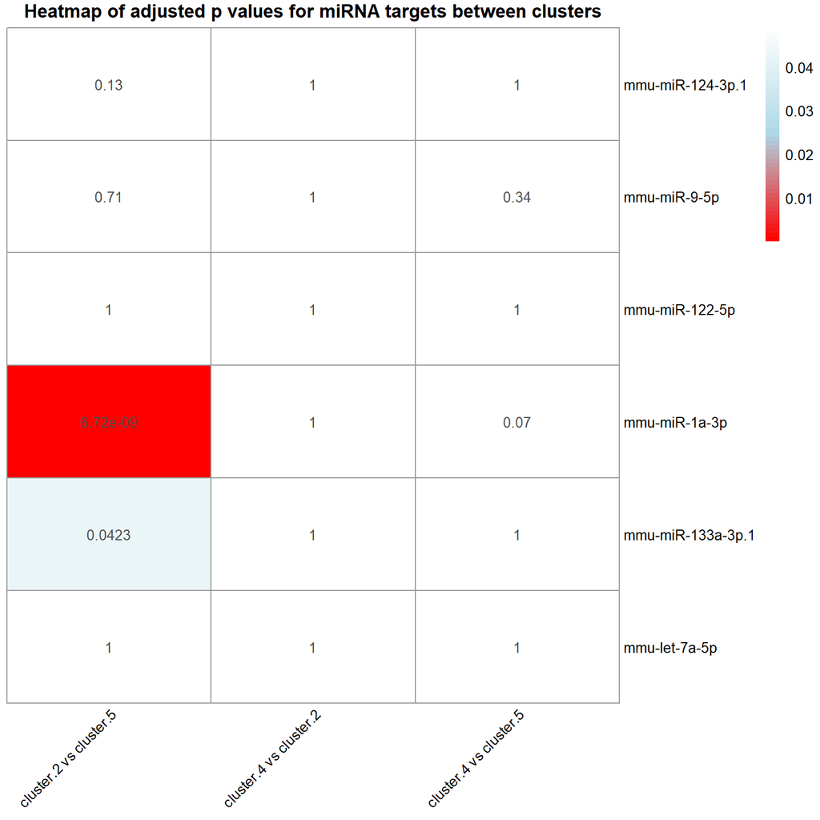

```r
# This Script calculates the adjusted pvals and generates a new heatmap of the adjusted pvals
# The significant values are displayed in red, the borderline ones in light blue and
# The non-significant onees in white.

# can be used on any heatmap that is generated

source("SPATA2_V4_FDR_Calculation.R")
```

```r
# The adjusted p value matrix can be viewed with the below commands

formatted_matrix <- apply(fdrs_with_n_matrix_transposed, 2, function(x) format(x, scientific = TRUE, digits = 4))
kable(formatted_matrix, format = "markdown")
```

|  | cluster.2 vs cluster.5 | cluster.4 vs cluster.2 | cluster.4 vs cluster.5 |
| --- | --- | --- | --- |
| mmu-miR-124-3p.1 | 1.334e-01 | 1e+00 | 1.000e+00 |
| mmu-miR-9-5p | 7.067e-01 | 1e+00 | 3.376e-01 |
| mmu-miR-122-5p | 1.000e+00 | 1e+00 | 1.000e+00 |
| mmu-miR-1a-3p | 6.720e-09 | 1e+00 | 7.084e-02 |
| mmu-miR-133a-3p.1 | 4.230e-02 | 1e+00 | 1.000e+00 |
| mmu-let-7a-5p | 1.000e+00 | 1e+00 | 1.000e+00 |